Source: https://archive.ics.uci.edu/dataset/544/estimation+of+obesity+levels+based+on+eating+habits+and+physical+condition

This dataset include data for the estimation of obesity levels in individuals from the countries of Mexico, Peru and Colombia, based on their eating habits and physical condition. The data contains 17 attributes and 2111 records, the records are labeled with the class variable NObesity (Obesity Level), that allows classification of the data using the values of Insufficient Weight, Normal Weight, Overweight Level I, Overweight Level II, Obesity Type I, Obesity Type II and Obesity Type III. 77% of the data was generated synthetically using the Weka tool and the SMOTE filter, 23% of the data was collected directly from users through a web platform.

| Variable Name | Role | Type | Demographic | Description | Units | Missing Values |
| --- | --- | --- | --- | --- | --- | --- |
| Gender | Feature | Categorical | Gender |  |  | no |
| Age | Feature | Continuous | Age |  |  | no |
| Height | Feature | Continuous |  |  |  | no |
| Weight | Feature | Continuous |  |  |  | no |
| family_history_with_overweight | Feature | Binary |  | Has a family member suffered or suffers from overweight? |  | no |
| FAVC | Feature | Binary |  | Do you eat high caloric food frequently? |  | no |
| FCVC | Feature | Integer |  | Do you usually eat vegetables in your meals? |  | no |
| NCP | Feature | Continuous |  | How many main meals do you have daily? |  | no |
| CAEC | Feature | Categorical |  | Do you eat any food between meals? |  | no |
| SMOKE | Feature | Binary |  | Do you smoke? |  | no |
| CH2O | Feature | Continuous |  | How much water do you drink daily? |  | no |
| SCC | Feature | Binary |  | Do you monitor the calories you eat daily? |  | no |
| FAF | Feature | Continuous |  | How often do you have physical activity? |  | no |
| TUE | Feature | Integer |  | How much time do you use technological devices such as cell phone, videogames, television, computer and others? |  | no |
| CALC | Feature | Categorical |  | How often do you drink alcohol? |  | no |
| MTRANS | Feature | Categorical |  | Which transportation do you usually use? |  | no |
| NObeyesdad | Target | Categorical |  | Obesity level |  |  |

# Import libraries and read data

```python
import pandas as pd
import numpy as np
import matplotlib.pyplot as plt
import seaborn as sns
from sklearn.preprocessing import LabelEncoder,OrdinalEncoder
```

```python
df=pd.read_csv('/content/estimation+of+obesity+levels+based+on+eating+habits+and+physical+condition.zip')
df
```

|  | Gender | Age | Height | Weight | family_history_with_overweight | FAVC | FCVC | NCP | CAEC | SMOKE | CH2O | SCC | FAF | TUE | CALC | MTRANS | NObeyesdad |
| --- | --- | --- | --- | --- | --- | --- | --- | --- | --- | --- | --- | --- | --- | --- | --- | --- | --- |
| 0 | Female | 21.000000 | 1.620000 | 64.000000 | yes | no | 2.0 | 3.0 | Sometimes | no | 2.000000 | no | 0.000000 | 1.000000 | no | Public_Transportation | Normal_Weight |
| 1 | Female | 21.000000 | 1.520000 | 56.000000 | yes | no | 3.0 | 3.0 | Sometimes | yes | 3.000000 | yes | 3.000000 | 0.000000 | Sometimes | Public_Transportation | Normal_Weight |
| 2 | Male | 23.000000 | 1.800000 | 77.000000 | yes | no | 2.0 | 3.0 | Sometimes | no | 2.000000 | no | 2.000000 | 1.000000 | Frequently | Public_Transportation | Normal_Weight |
| 3 | Male | 27.000000 | 1.800000 | 87.000000 | no | no | 3.0 | 3.0 | Sometimes | no | 2.000000 | no | 2.000000 | 0.000000 | Frequently | Walking | Overweight_Level_I |
| 4 | Male | 22.000000 | 1.780000 | 89.800000 | no | no | 2.0 | 1.0 | Sometimes | no | 2.000000 | no | 0.000000 | 0.000000 | Sometimes | Public_Transportation | Overweight_Level_II |
| ... | ... | ... | ... | ... | ... | ... | ... | ... | ... | ... | ... | ... | ... | ... | ... | ... | ... |
| 2106 | Female | 20.976842 | 1.710730 | 131.408528 | yes | yes | 3.0 | 3.0 | Sometimes | no | 1.728139 | no | 1.676269 | 0.906247 | Sometimes | Public_Transportation | Obesity_Type_III |
| 2107 | Female | 21.982942 | 1.748584 | 133.742943 | yes | yes | 3.0 | 3.0 | Sometimes | no | 2.005130 | no | 1.341390 | 0.599270 | Sometimes | Public_Transportation | Obesity_Type_III |
| 2108 | Female | 22.524036 | 1.752206 | 133.689352 | yes | yes | 3.0 | 3.0 | Sometimes | no | 2.054193 | no | 1.414209 | 0.646288 | Sometimes | Public_Transportation | Obesity_Type_III |
| 2109 | Female | 24.361936 | 1.739450 | 133.346641 | yes | yes | 3.0 | 3.0 | Sometimes | no | 2.852339 | no | 1.139107 | 0.586035 | Sometimes | Public_Transportation | Obesity_Type_III |
| 2110 | Female | 23.664709 | 1.738836 | 133.472641 | yes | yes | 3.0 | 3.0 | Sometimes | no | 2.863513 | no | 1.026452 | 0.714137 | Sometimes | Public_Transportation | Obesity_Type_III |

2111 rows × 17 columns

# Data analysis

First we round some variables that should be integers, but they have been calculated as the mean of their habits.

```python
df.NCP=df.NCP.round()
df.FAF=df.FAF.round()
df.TUE=df.TUE.round()
```

Then we simplify some variable names and the names of the categories of the target variable, in order to make the data analysis and visualisation easier.

```python
df.rename(columns={'family_history_with_overweight':'FHO'},inplace=True)
```

```python
mapping = {'Normal_Weight':'NW', 'Overweight_Level_I':'OW1', 'Overweight_Level_II':'OW2',
       'Obesity_Type_I':'O1', 'Insufficient_Weight':'IW', 'Obesity_Type_II':'O2',
       'Obesity_Type_III':'O3'
}
```

```python
df.replace({'NObeyesdad':mapping},inplace=True)
```

```python
df.FCVC
```

```
0       2.0
1       3.0
2       2.0
3       3.0
4       2.0
       ...
2106    3.0
2107    3.0
2108    3.0
2109    3.0
2110    3.0
Name: FCVC, Length: 2111, dtype: float64
```

Now we encode the categorical variables. OrdinalEncoder is for converting features, while LabelEncoder is for converting target variable.

```python
df_ct=df[['Gender','SMOKE','FHO',
                          'FAVC','CAEC','SCC',
                          'CALC','MTRANS']]
Y = df['NObeyesdad']
df_categorized = df.copy()
```

```python
oe= OrdinalEncoder()
df_categorized[['Gender','SMOKE','FHO','FAVC','CAEC','SCC',
                          'CALC','MTRANS']] = oe.fit_transform(df_ct)
le = LabelEncoder()
df_categorized['NObeyesdad'] = le.fit_transform(Y)
```

```python
df_categorized
```

|  | Gender | Age | Height | Weight | FHO | FAVC | FCVC | NCP | CAEC | SMOKE | CH2O | SCC | FAF | TUE | CALC | MTRANS | NObeyesdad |
| --- | --- | --- | --- | --- | --- | --- | --- | --- | --- | --- | --- | --- | --- | --- | --- | --- | --- |
| 0 | 0.0 | 21.000000 | 1.620000 | 64.000000 | 1.0 | 0.0 | 2.0 | 3.0 | 2.0 | 0.0 | 2.000000 | 0.0 | 0.0 | 1.0 | 3.0 | 3.0 | 1 |
| 1 | 0.0 | 21.000000 | 1.520000 | 56.000000 | 1.0 | 0.0 | 3.0 | 3.0 | 2.0 | 1.0 | 3.000000 | 1.0 | 3.0 | 0.0 | 2.0 | 3.0 | 1 |
| 2 | 1.0 | 23.000000 | 1.800000 | 77.000000 | 1.0 | 0.0 | 2.0 | 3.0 | 2.0 | 0.0 | 2.000000 | 0.0 | 2.0 | 1.0 | 1.0 | 3.0 | 1 |
| 3 | 1.0 | 27.000000 | 1.800000 | 87.000000 | 0.0 | 0.0 | 3.0 | 3.0 | 2.0 | 0.0 | 2.000000 | 0.0 | 2.0 | 0.0 | 1.0 | 4.0 | 5 |
| 4 | 1.0 | 22.000000 | 1.780000 | 89.800000 | 0.0 | 0.0 | 2.0 | 1.0 | 2.0 | 0.0 | 2.000000 | 0.0 | 0.0 | 0.0 | 2.0 | 3.0 | 6 |
| ... | ... | ... | ... | ... | ... | ... | ... | ... | ... | ... | ... | ... | ... | ... | ... | ... | ... |
| 2106 | 0.0 | 20.976842 | 1.710730 | 131.408528 | 1.0 | 1.0 | 3.0 | 3.0 | 2.0 | 0.0 | 1.728139 | 0.0 | 2.0 | 1.0 | 2.0 | 3.0 | 4 |
| 2107 | 0.0 | 21.982942 | 1.748584 | 133.742943 | 1.0 | 1.0 | 3.0 | 3.0 | 2.0 | 0.0 | 2.005130 | 0.0 | 1.0 | 1.0 | 2.0 | 3.0 | 4 |
| 2108 | 0.0 | 22.524036 | 1.752206 | 133.689352 | 1.0 | 1.0 | 3.0 | 3.0 | 2.0 | 0.0 | 2.054193 | 0.0 | 1.0 | 1.0 | 2.0 | 3.0 | 4 |
| 2109 | 0.0 | 24.361936 | 1.739450 | 133.346641 | 1.0 | 1.0 | 3.0 | 3.0 | 2.0 | 0.0 | 2.852339 | 0.0 | 1.0 | 1.0 | 2.0 | 3.0 | 4 |
| 2110 | 0.0 | 23.664709 | 1.738836 | 133.472641 | 1.0 | 1.0 | 3.0 | 3.0 | 2.0 | 0.0 | 2.863513 | 0.0 | 1.0 | 1.0 | 2.0 | 3.0 | 4 |

2111 rows × 17 columns

Let's calculate the correlation between the different variables.

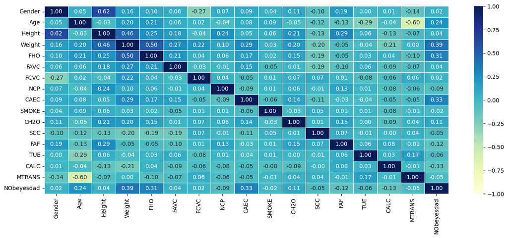

```python
plt.figure(figsize=(16, 6))
sns.heatmap(df_categorized.corr(),annot=True, cmap="YlGnBu",
            vmin=-1,vmax=1,fmt=".2f", linewidth=.5);
```

Now let's analyze the data using different data visualisation technicques, like histograms.

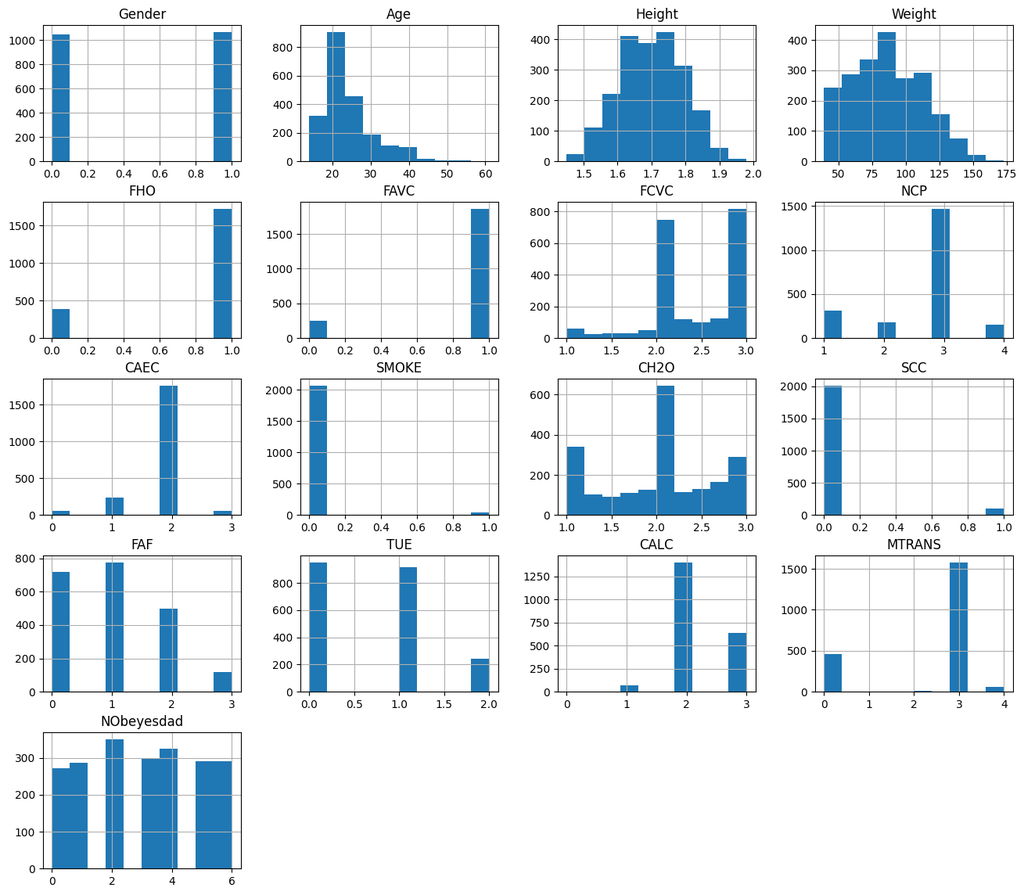

```python
df_categorized.hist(figsize=(16,14)); #";"" to hide array([...])
```

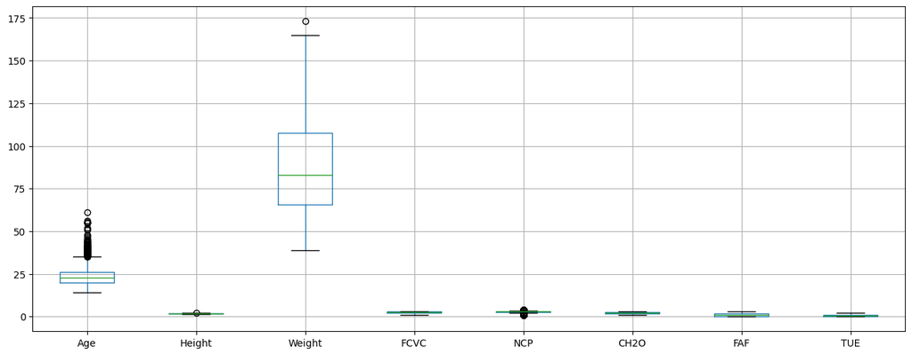

```python
df.boxplot(figsize=(16,6));
```

[figure not shown]

```python
df_categorized.plot(kind='scatter', x='Weight', y='family_history_with_overweight', s=32, alpha=.8)
plt.gca().spines[['top', 'right',]].set_visible(False)
```

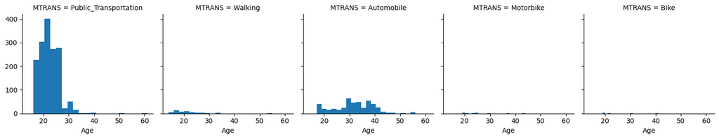

```python
g = sns.FacetGrid(df, col='MTRANS')
g.map(plt.hist, 'Age', bins=20);
```

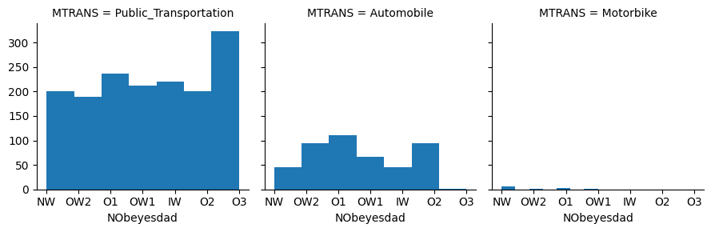

```python
g = sns.FacetGrid(df.loc[df_categorized['MTRANS'].isin([0,2,3])], col='MTRANS')
g.map(plt.hist, 'NObeyesdad', bins=7);
```

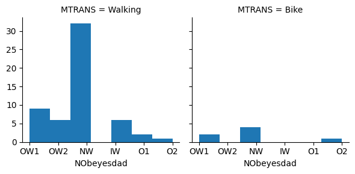

```python
g = sns.FacetGrid(df.loc[df_categorized['MTRANS'].isin([1,4])], col='MTRANS')
g.map(plt.hist, 'NObeyesdad', bins=7);
```

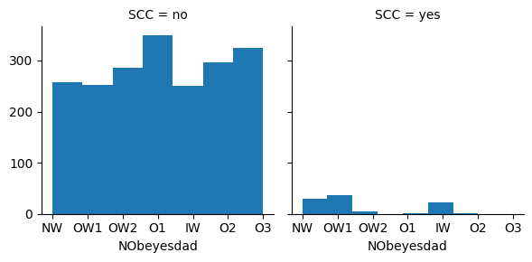

```python
g = sns.FacetGrid(df, col='SCC')
g.map(plt.hist, 'NObeyesdad', bins=7);
```

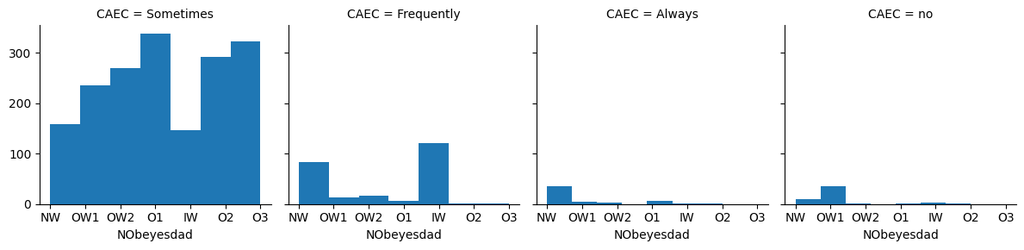

```python
g = sns.FacetGrid(df, col='CAEC')
g.map(plt.hist, 'NObeyesdad', bins=7);
```

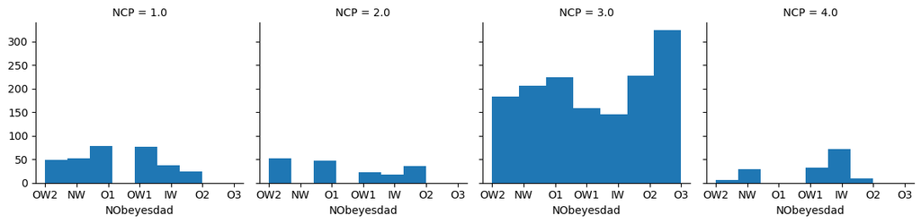

```python
g = sns.FacetGrid(df, col='NCP')
g.map(plt.hist, 'NObeyesdad', bins=7);
```

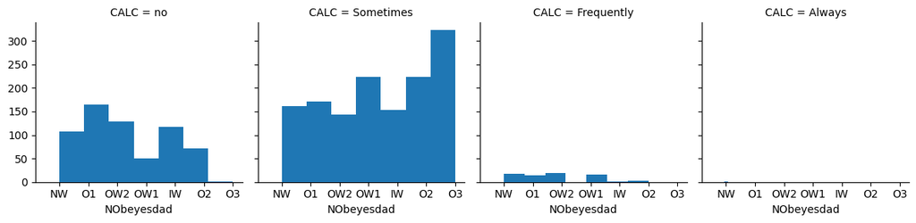

```python
g = sns.FacetGrid(df, col='CALC')
g.map(plt.hist, 'NObeyesdad', bins=7);
```

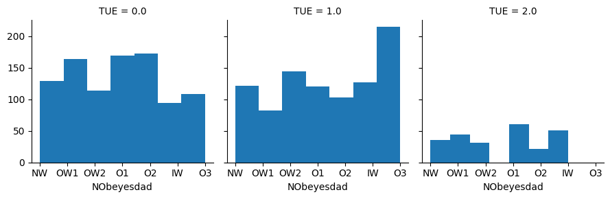

```python
g = sns.FacetGrid(df, col='TUE')
g.map(plt.hist, 'NObeyesdad', bins=7);
```

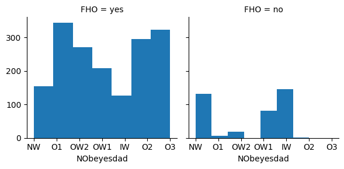

```python
g = sns.FacetGrid(df, col='FHO')
g.map(plt.hist, 'NObeyesdad', bins=7);
```

## Modelling

Now let's try some different classic classification models. We are going to try them using different model parameters throught the GridSearch technicque, which tests each model with the asked parameters

```python
from sklearn.linear_model import LogisticRegression,Perceptron,RidgeClassifier, SGDClassifier
from sklearn.ensemble import RandomForestClassifier
from sklearn.metrics import accuracy_score
from sklearn.model_selection import train_test_split
```

```python
train_len = round(len(df)*0.8)
```

```python
features_columns=df_categorized.columns[~df_categorized.columns.isin(['NObeyesdad','Height','Weight'])]
X,Y = df_categorized[features_columns],df_categorized['NObeyesdad']
X_train,X_test,Y_train,Y_test = train_test_split(X,Y,test_size= 0.2, random_state=2)
```

```python
from sklearn.model_selection import GridSearchCV
parameters = {'solver':('lbfgs', 'liblinear', 'newton-cholesky', 'sag', 'saga'), 'C':[0.1,0.5,1,10],'max_iter':[2000]}
lr = LogisticRegression()
clf = GridSearchCV(lr, parameters)
```

```python
models = [clf,          Perceptron(),RidgeClassifier(), SGDClassifier(),RandomForestClassifier()]
accuracy = []
for model in models:
  model.fit(X_train, Y_train);
  pred=model.predict(X_test)
  accuracy.append(accuracy_score(Y_test,pred))
accuracy
```

[output not shown]

[output cut: 49 more lines]

[output not shown]

```
[0.6052009456264775,
 0.3664302600472813,
 0.5673758865248227,
 0.5390070921985816,
 0.8486997635933806]
```

The best model is the random forest. Let's try it now only with the most correlated variables.

```python
com=pd.DataFrame(Y_test)
com['pred']=pred
```

```python
com
```

|  | NObeyesdad | pred |
| --- | --- | --- |
| 1523 | 3 | 3 |
| 1997 | 4 | 4 |
| 460 | 1 | 1 |
| 137 | 2 | 6 |
| 1092 | 6 | 6 |
| ... | ... | ... |
| 454 | 1 | 1 |
| 288 | 1 | 1 |
| 1218 | 2 | 2 |
| 768 | 5 | 5 |
| 1330 | 2 | 2 |

423 rows × 2 columns

```python
df_pre=df_categorized.corr().NObeyesdad.apply(np.fabs).sort_values(ascending=False)
df_pr=df_pre[df_pre>0.1]
df_prep=df_categorized[df_pr.index.values]
```

```python
features_columns=df_prep.columns[~df_prep.columns.isin(['NObeyesdad'])]
X,Y = df_prep[features_columns.values],df_prep['NObeyesdad']
X_train,X_test,Y_train,Y_test = X[:train_len],X[train_len:],Y[:train_len],Y[train_len:]
```

```python
models = [LogisticRegression(),Perceptron(),RidgeClassifier(), SGDClassifier(),RandomForestClassifier()]
accuracy = []
for model in models:
  print(model)
  model.fit(X_train, Y_train)
  pred=model.predict(X_test)
  accuracy.append(accuracy_score(Y_test,pred))
accuracy
```

```
LogisticRegression()
Perceptron()
RidgeClassifier()
```

```
SGDClassifier()
RandomForestClassifier()
```

```
[0.36729857819905215,
 0.0,
 0.16824644549763032,
 0.0971563981042654,
 0.6872037914691943]
```

```python
accuracy
```

[output not shown]

We can check that the accuracy is lower with only the most correlated variables, so let's preserve the old variables.

It's evident that if we know the height and the weight of a person, we know through the BMI if someone is obese or not. So, let's discard them and try the models again. We are using again the Random Forest, but this time we are trying it with a GridSearch to find the best parameters.

```python
features_columns=df_categorized.columns[~df_categorized.columns.isin(['NObeyesdad','Height','Weight'])]
X,Y = df_categorized[features_columns],df_categorized['NObeyesdad']
X_train,X_test,Y_train,Y_test = train_test_split(X,Y,test_size= 0.1, random_state=2)
```

```python
parameters = {'max_depth':[None,2,4,6],'n_estimators':[100,500,1000]}
rf = RandomForestClassifier()
clf = GridSearchCV(rf, parameters,cv=3,return_train_score=True)
```

```python
clf.fit(X_train,Y_train)
pred=clf.predict(X_test)
print(accuracy_score(Y_test,pred))
```

```
0.8867924528301887
```

```python
print(clf.best_score_)
print(clf.best_params_)
```

```
0.8193786203264876
{'max_depth': None, 'n_estimators': 1000}
```

Thus, we can conclude that we can predict with certain accuracy with the variables that we have if someone can have overweight or not using the features that the dataset has provided to us.